# analysis

Luca Rossi

2024-02-15

# Analyis

## City Level

According to the analysis before the towns identified with numbers: 1,2,6 are similar for carCrash and pedestrianDeath, or in another way, they have parallel trends before the treatment

### Diff-in-Diff

```r
# we create the variable treated if city is treated

traffic_city <- traffic_city %>%
  mutate(treated = if_else(city == 1, 1, 0))

traffic_city <- traffic_city %>%
  mutate(after = if_else(date >= as.Date("2021-06-01"),1, 0))

# similar towns subset
similar_towns <-subset(traffic_city,city %in%c(1,2,6))
```

We create a dummy variable called treated that takes values 1 if the city is city 1 and 0 otherwise

Let’s take pedestrianDeath as independent variable and write a simple difference-in-difference regression

$$Y = \beta_0 + \beta_1 \times
\text{Treatment} + \beta_2 \times \text{Post} + \beta_3 \times
\text{Treatment} \times \text{Post} + \epsilon$$

where:

- $Y$ is the dependent variable,
- $\beta_0$ is the intercept,
- $\beta_1$ represents the effect of the treatment (before and after),
- $\beta_2$ captures the time effect (difference between pre and post),
- $\beta_3$ is the interaction term that provides the Difference-in-Differences estimator (the effect of the treatment after the treatment relative to before),
- $\text{Treatment}$ is a dummy variable indicating whether the observation is in the treatment group or control group,
- $\text{Post}$ is a dummy variable indicating the post-treatment period,
- $\epsilon$ represents the error term, capturing all other factors affecting $Y$ not included in the model.

|  | city_regression_pe.. |
| --- | --- |
| Dependent Var.: | pedestrianDeath |
| Constant | 0.0004*** (6.07e-6) |
| after | -2.5e-6 (8.58e-6) |
| treated | 4.84e-7 (1.05e-5) |
| after x treated | -0.0001*** (1.49e-5) |
| _______________ | ____________________ |
| S.E. type | IID |
| Observations | 54 |
| R2 | 0.74343 |
| Adj. R2 | 0.72804 |

Interpreting the results:

We have a constant value of 0.0004 deaths every week which is statistically significant at 1% level and after x treated -0.0001 with significance level also at 1%.

So After the treatment we have a decrease in deaths of 0.0001.

Small recap:

- the significance codes stands for p values < 0.01 *** , p < 0.05 ** , p < 0.10 *)
- More precisely, a study’s defined significance level, denoted by $\alpha$ , is the probability of the study rejecting the null hypothesis, given that the null hypothesis is true; and the p-value of a result, p , is the probability of obtaining a result at least as extreme, given that the null hypothesis is true.

But what does this mean?

To have a better understanding we can run the regression using the logarithm, to get the variation

$$log(Y) = \beta_0 + \beta_1 \times
\text{Treatment} + \beta_2 \times \text{Post} + \beta_3 \times
\text{Treatment} \times \text{Post} + \epsilon$$

|  | city_regression_pe.. | city_regression_pe.. |
| --- | --- | --- |
| Dependent Var.: | pedestrianDeath | log(pedestrianDeath) |
| Constant | 0.0004*** (6.07e-6) | -7.855*** (0.0159) |
| after | -2.5e-6 (8.58e-6) | -0.0070 (0.0225) |
| treated | 4.84e-7 (1.05e-5) | 0.0019 (0.0276) |
| after x treated | -0.0001*** (1.49e-5) | -0.3406*** (0.0390) |
| _______________ | ____________________ | ____________________ |
| S.E. type | IID | IID |
| Observations | 54 | 54 |
| R2 | 0.74343 | 0.79513 |
| Adj. R2 | 0.72804 | 0.78284 |

##### Interpreting the coefficients:

Method 1:

$\text% \Delta Y = (exp(\beta_3)-1) * 100$

Method 2:

$\text% \Delta Y = \beta_3 * 100$

Now we can see that after the treatment we have a 34% decrease in deaths in the treated city after reducing the speed in city 1

Using the same on car crashes:

|  | city_regression_car | city_regression_c.. |
| --- | --- | --- |
| Dependent Var.: | carCrash | log(carCrash) |
| Constant | 0.0029*** (2.07e-5) | -5.837*** (0.0074) |
| after | -3.92e-6 (2.93e-5) | -0.0011 (0.0105) |
| treated | -2.62e-6 (3.58e-5) | -0.0010 (0.0128) |
| after x treated | -0.0009*** (5.07e-5) | -0.3497*** (0.0181) |
| _______________ | ____________________ | ___________________ |
| S.E. type | IID | IID |
| Observations | 54 | 54 |
| R2 | 0.93559 | 0.94928 |
| Adj. R2 | 0.93172 | 0.94623 |

We obtain similar results to pedestrianDeath regression

### Event Study

Now we are going to perform an Event study at city level to visually represent the results

What it is an event study?

*An event study is a statistical method to assess the impact of an event (also referred to as a “treatment”)*

for reference: https://lost-stats.github.io/Model_Estimation/Research_Design/event_study.html

My code will be in R, but you can use the code in python provided by this guy.

- $\text{pedestrianDeath}$ is the dependent variable
- $\alpha$ is the intercept of the linear model
- $\beta$ is the slope of the linear model that describes the effect of treatment
- $\epsilon_{i,t}$ represents the error terms, which are assumed to be normally distributed with mean zero and constant variance

In simpler terms, the event study will provide a coefficient $\beta$ for each time observation (could be days, months years…)

You should obtain something like this:

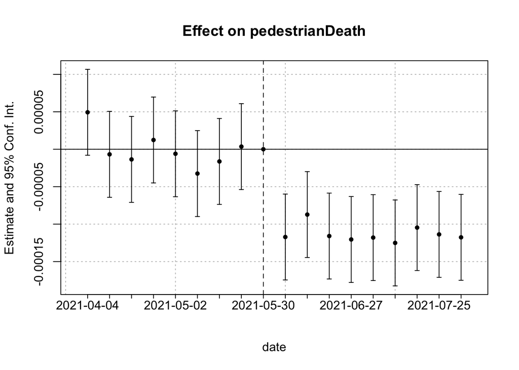

As you can notice from the values on the y-axis, it is not very comprehensible, since, luckily, not many people are dying every week from car crashes.

The interpretation is that after the change in speed there are 0.00015 deaths due to cars in the city treated with respect to the others controlled.

As you can see the confidence intervals are quite large we can “control” for other characteristics:

$$Y = \alpha + \beta \times After_t +
\chi_{i} + \epsilon_{i_t}$$
Here $\chi$ stands for the vector of control variables that in this case are log(population) + log(size) + log(popDensity)

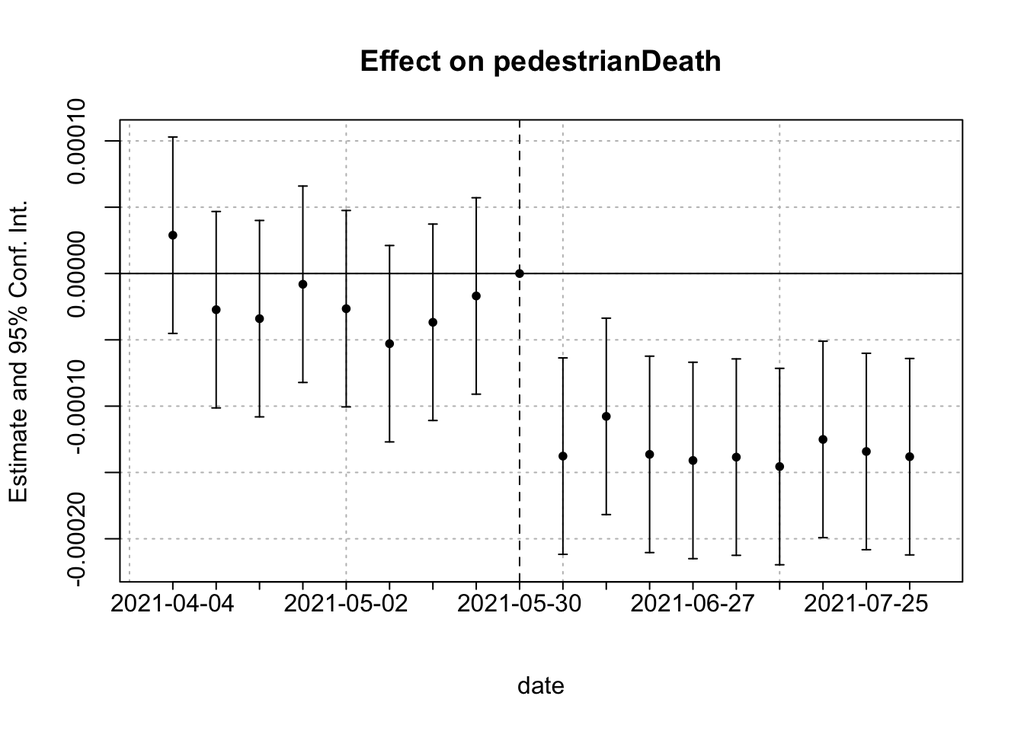

To have a better understanding, we can use the log to have the variation

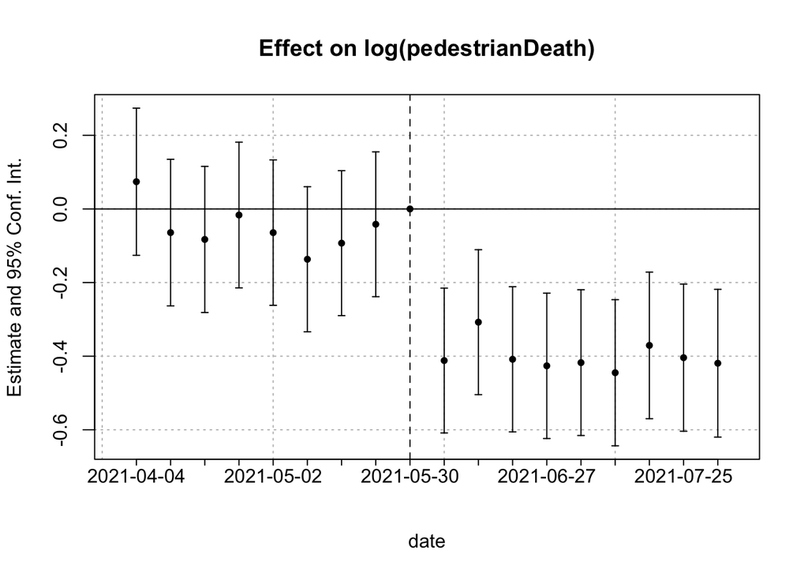

The confidence intervals cross the 0 line before the treatment, so we can claim there is no effect before the treatment with respect to the point 0 (marked with dashed line)

Using date fixed effects to keep into account unobserved characteristics

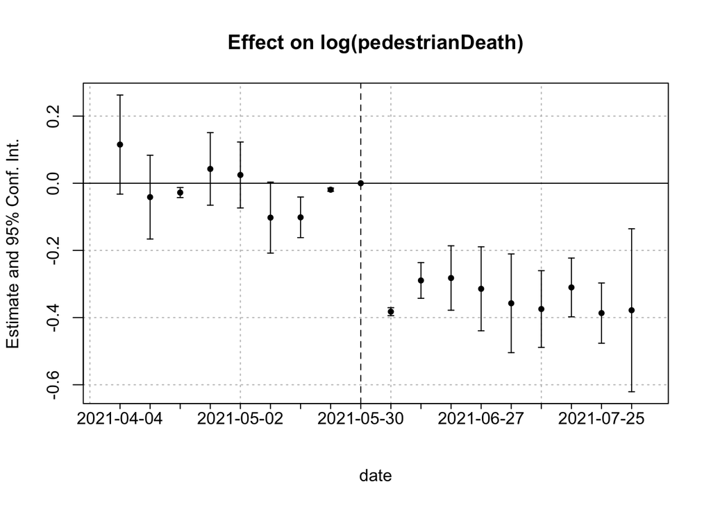

As you can see, the confidence intervals are way smaller when using fixed effects

Doing the same for car crash

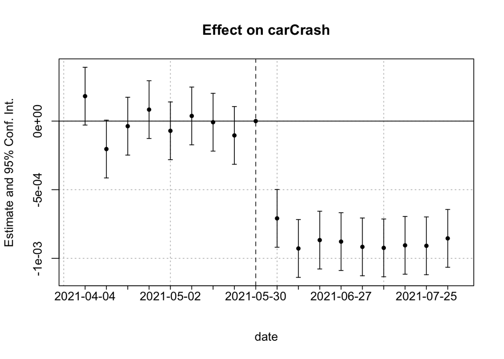

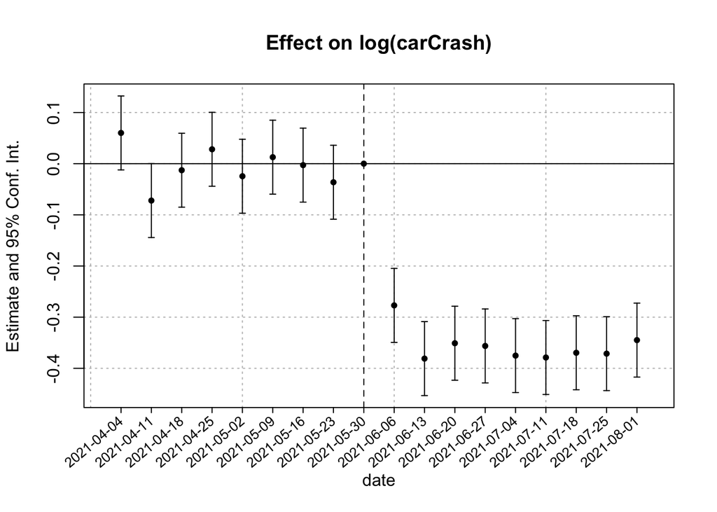

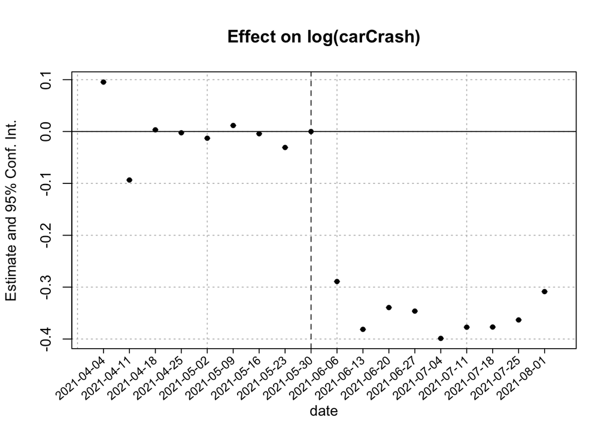

Now we perform the study at station level, we analyze the treated stations against the non-treated ones. The treated one will assume value 1 if are in city 1 and are not 4 and 7 (we saw that the speed was not altered in them).

# Station level

## Whitin the same city

### Difference-in-difference

Now we perform the analysis in the same city, considering all the stations as treated, except for 4 and 7, that are the controls.

|  | city_regression_p.. | city_regression_pe.. |
| --- | --- | --- |
| Dependent Var.: | pedestrianDeath | log(pedestrianDeath) |
| Constant | 0.0004*** (1.71e-5) | -7.840*** (0.0509) |
| after | -2.39e-5 (2.42e-5) | -0.0640 (0.0720) |
| treated | -1.86e-5 (1.91e-5) | -0.0412 (0.0570) |
| after x treated | -0.0001*** (2.7e-5) | -0.3792*** (0.0805) |
| _______________ | ___________________ | ____________________ |
| S.E. type | IID | IID |
| Observations | 180 | 180 |
| R2 | 0.47763 | 0.51265 |
| Adj. R2 | 0.46872 | 0.50434 |

|  | city_regression_ca.. | city_regression_c.. |
| --- | --- | --- |
| Dependent Var.: | carCrash | log(carCrash) |
| Constant | 0.0029*** (4.58e-5) | -5.858*** (0.0194) |
| after | 4.24e-5 (6.48e-5) | 0.0144 (0.0275) |
| treated | 6.54e-5 (5.12e-5) | 0.0229 (0.0217) |
| after x treated | -0.0011*** (7.25e-5) | -0.4822*** (0.0307) |
| _______________ | ____________________ | ___________________ |
| S.E. type | IID | IID |
| Observations | 180 | 180 |
| R2 | 0.88244 | 0.88547 |
| Adj. R2 | 0.88044 | 0.88351 |

##### Interpreting the results:

We have a 38% decrease in deaths and 48% Decrease in car crashes in the treated stations in Azzurropoli, using method 2

### Event study

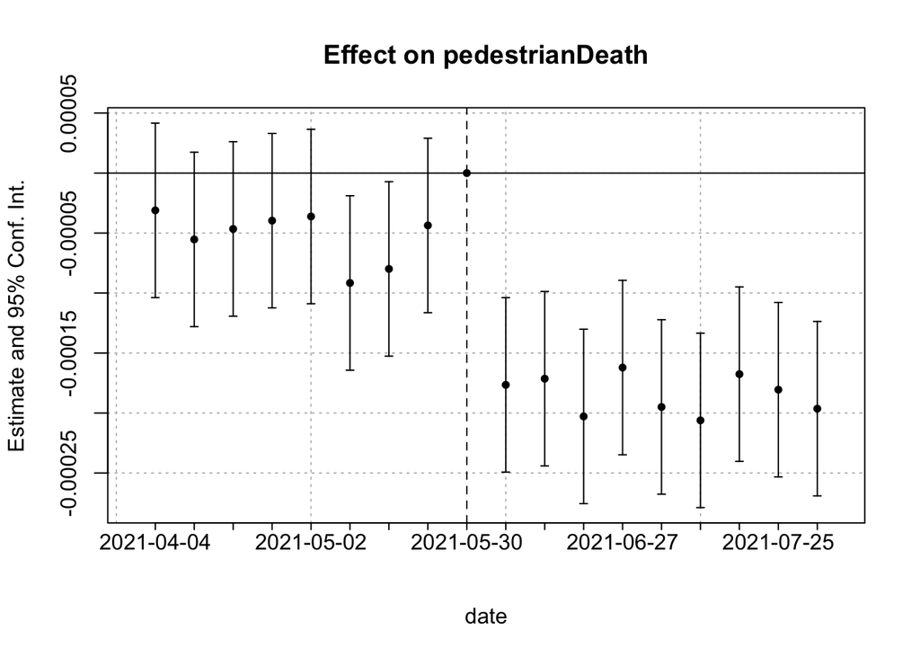

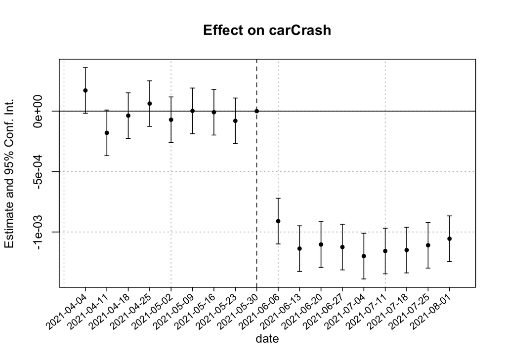